```python
%pylab inline
```

# Importing the libraries

```python
import dataiku
import numpy as np
import pandas as pd
import sklearn as sk
import matplotlib.pyplot as plt
import seaborn as sns
import datetime
from collections import defaultdict
from itertools import (compress, combinations)

import xgboost as xgb
from xgboost import plot_importance

from sklearn.base import clone
from sklearn.cross_validation import train_test_split
from sklearn.preprocessing import (OneHotEncoder, LabelEncoder,
                                   MinMaxScaler,StandardScaler,Imputer)
from sklearn.feature_selection import chi2
from sklearn.metrics import (mutual_info_score, accuracy_score, r2_score)
from sklearn.decomposition import PCA
from sklearn.cluster import KMeans
from sklearn.metrics.pairwise import euclidean_distances
from sklearn.feature_extraction.text import CountVectorizer
from sklearn.neighbors import KNeighborsClassifier
from sklearn import linear_model

# dataiku related libraries
import dataiku.core.pandasutils as pdu

# setting pandas options
pd.set_option('display.width', 3000)
pd.set_option('display.max_rows', 200)
pd.set_option('display.max_columns', 200)
```

# Exporting the modelling dataset

```python
ar = dataiku.Dataset("CCAP_CAD_DAS_DEV")
ar_df = ar.get_dataframe()
df_copy = ar_df
```

# Let's sneakpeak the data and look at initial statistics

```python
ar_df.shape
```

[output not shown]

```python
ar_df.head()
```

|  | CCAPS_ref_no | time_mth_id | MC_appl_typ | MC_NCCS_LOB_cd | channel_sid | related_CCAPS_ref_no | cur_appl_state | prev_appl_state | EIN_sid | MC_src_prod_id | pri_CCAPS_prod_cd | MC_CCAPS_prod_cd | MC_CCAPS_prod_pos_nbr | MC_rpt_cd | xsell_pos_id | MC_xsell_catg | scorecard_post_CBR_catg_cd | record_typ | scan_list_loc_cd | scan_list_br_cd | scan_list_state_cd | scan_list_user_id | scan_list_hold_dt | scan_list_CCAPS_ref_no | accs_cntl_cnt | prefill_CCAPS_ref_no | priority_sort_cd | appl_cd_1 | appl_cd_2 | … |
| --- | --- | --- | --- | --- | --- | --- | --- | --- | --- | --- | --- | --- | --- | --- | --- | --- | --- | --- | --- | --- | --- | --- | --- | --- | --- | --- | --- | --- | --- | --- |
| 0 | 98081151745420 | 200904 | $ | NaN | 67 | NaN | I01 | F15 | 0 | NaN | PLOC | $ | 0 | NaN | 0 | $ | 0 | 12 | 980811 | 51745 | 420 | NaN | 19MAR2009 | NaN | 185 | 98072981749190 | 6 | J | NaN | … |
| 1 | 98082141032440 | 200905 | $ | NaN | 67 | NaN | I01 | F90 | 0 | NaN | PLCI | $ | 0 | NaN | 0 | $ | 0 | 12 | 980821 | 41032 | 440 | NaN | 24APR2009 | NaN | 355 | 9806229165116F | 6 | I | NaN | … |
| 2 | 98082461136011 | 200901 | $ | NaN | 67 | NaN | I01 | F14 | 0 | NaN | PLCI | $ | 0 | NaN | 2000 | $ | 0 | 12 | 980824 | 61136 | 011 | NaN | 20JAN2009 | NaN | 247 | 9807197194754D | 6 | I | NaN | … |
| 3 | 98082542022270 | 200901 | $ | NaN | 67 | NaN | I01 | F10 | 0 | NaN | PLOC | $ | 0 | NaN | 2000 | $ | 0 | 12 | 980825 | 42022 | 270 | NaN | 04DEC2008 | NaN | 412 | NaN | 6 | J | NaN | … |
| 4 | 98082681008070 | 200903 | $ | NaN | 0 | NaN | I01 | F90 | 0 | NaN | PLOC | $ | 0 | NaN | 2000 | $ | 0 | 12 | 102030 | D0387 | F90 | 3ME7SB | 27FEB2009 | 98082681008070 | 100 | NaN | 1 | I | NaN | … |

5 rows × 2335 columns

# Distribution of accounts

```
Text(0.5,1,'Distribution of accounts')
```

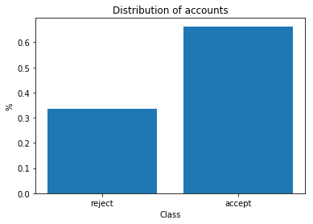

```python
pop_count = ar_df.groupby("accept")["accept"].count()
n = ar_df.shape[0]
pop_prcnt = pop_count/n

plt.bar(x = ["reject", "accept"] , height = pop_prcnt)
plt.xlabel("Class")
plt.ylabel("%")
plt.title("Distribution of accounts")
```

Let's do a basic info rundown of the files

```python
ar_df.info()
```

```
<class 'pandas.core.frame.DataFrame'>
RangeIndex: 183213 entries, 0 to 183212
Columns: 2335 entries, CCAPS_ref_no to cnsmr_prpsl_bkrp_cd
dtypes: float64(1880), int64(125), object(330)
memory usage: 3.2+ GB
```

Let's skim over the numerical variables and summarise them.

```python
ar_df.describe()
```

|  | time_mth_id | channel_sid | EIN_sid | MC_CCAPS_prod_pos_nbr | MC_rpt_cd | xsell_pos_id | scorecard_post_CBR_catg_cd | record_typ | scan_list_loc_cd | accs_cntl_cnt | priority_sort_cd | loc_company_cd | loc_division_cd | loc_serv_ctr_cd | owning_transit_sid | sales_transit_sid | cls_transit_sid | enter_adjud_days | inactive_tm | enter_inactive_days | arch_dt | enter_cls_days | MC_enter_book_days | MC_club_id | rqst_resid_purch_amt | rqst_tot_amt | rqst_tot_mth_pymt | rqst_tot_mtg_pymt | aprv_tot_rqst_amt | … |
| --- | --- | --- | --- | --- | --- | --- | --- | --- | --- | --- | --- | --- | --- | --- | --- | --- | --- | --- | --- | --- | --- | --- | --- | --- | --- | --- | --- | --- | --- | --- |
| count | 183213.000000 | 183213.000000 | 183213.000000 | 183213.000000 | 21455.000000 | 183213.000000 | 183213.000000 | 183213.000000 | 183213.000000 | 183213.000000 | 183213.000000 | 183213.0 | 183213.000000 | 183213.000000 | 183213.000000 | 183213.000000 | 183213.000000 | 174218.000000 | 0.0 | 164162.000000 | 0.0 | 1267.000000 | 9368.000000 | 0.0 | 1.832130e+05 | 1.832130e+05 | 183213.000000 | 183213.000000 | 1.832130e+05 | … |
| mean | 200993.159470 | 52.466222 | 27.868890 | 0.251450 | 0.275134 | 674.980651 | 0.702625 | 11.792034 | 609909.983184 | 124.396014 | 5.454487 | 10.0 | 24.296693 | 34.786942 | 14232.941118 | 12377.814042 | 14164.298811 | 8.200416 | NaN | 70.604665 | NaN | 14.681137 | 14.427733 | NaN | 1.193939e+04 | 3.925187e+04 | 686.913188 | 27.580870 | 3.812175e+04 | … |
| std | 78.779128 | 30.075888 | 1172.010934 | 0.704791 | 0.446592 | 966.435570 | 1.929271 | 0.610478 | 433789.835516 | 96.947698 | 1.802725 | 0.0 | 12.388908 | 20.502232 | 6515.409581 | 6896.422866 | 6573.716299 | 25.314371 | NaN | 66.950071 | NaN | 26.436385 | 27.673355 | NaN | 9.757324e+04 | 1.162023e+05 | 2281.113974 | 274.866083 | 1.050172e+05 | … |
| min | 200901.000000 | 0.000000 | 0.000000 | 0.000000 | 0.000000 | 0.000000 | 0.000000 | 10.000000 | 100000.000000 | 0.000000 | 0.000000 | 10.0 | 10.000000 | 10.000000 | 1.000000 | 1.000000 | 1.000000 | 1.000000 | NaN | 1.000000 | NaN | 1.000000 | 1.000000 | NaN | 0.000000e+00 | 0.000000e+00 | 0.000000 | 0.000000 | 2.800000e-01 | … |
| 25% | 200908.000000 | 15.000000 | 0.000000 | 0.000000 | 0.000000 | 0.000000 | 0.000000 | 12.000000 | 103060.000000 | 58.000000 | 6.000000 | 10.0 | 20.000000 | 20.000000 | 13738.000000 | 5874.000000 | 13648.000000 | 1.000000 | NaN | 22.000000 | NaN | 1.000000 | 2.000000 | NaN | 0.000000e+00 | 1.000029e+04 | 200.000000 | 0.000000 | 1.000158e+04 | … |
| 50% | 201005.000000 | 67.000000 | 0.000000 | 0.000000 | 0.000000 | 0.000000 | 0.000000 | 12.000000 | 980906.000000 | 100.000000 | 6.000000 | 10.0 | 20.000000 | 30.000000 | 16939.000000 | 16545.000000 | 16934.000000 | 1.000000 | NaN | 53.000000 | NaN | 6.000000 | 7.000000 | NaN | 0.000000e+00 | 2.000029e+04 | 400.000000 | 0.000000 | 2.250217e+04 | … |
| 75% | 201101.000000 | 67.000000 | 0.000000 | 0.000000 | 1.000000 | 2000.000000 | 0.000000 | 12.000000 | 981009.000000 | 162.000000 | 6.000000 | 10.0 | 30.000000 | 60.000000 | 17592.000000 | 17504.000000 | 17584.000000 | 6.000000 | NaN | 105.000000 | NaN | 14.000000 | 15.000000 | NaN | 0.000000e+00 | 3.502732e+04 | 700.000000 | 0.000000 | 4.300196e+04 | … |
| max | 201109.000000 | 300.000000 | 71866.000000 | 5.000000 | 1.000000 | 2340.000000 | 6.000000 | 12.000000 | 981127.000000 | 997.000000 | 9.000000 | 10.0 | 70.000000 | 70.000000 | 25643.000000 | 25643.000000 | 25643.000000 | 2750.000000 | NaN | 3029.000000 | NaN | 353.000000 | 731.000000 | NaN | 1.300000e+07 | 1.400001e+07 | 324683.330000 | 24486.870000 | 1.400001e+07 | … |

8 rows × 2005 columns

# Find the proportion of missing values for each column

```python
# This function will calculate the percentage of missing values across the dataset
# and list the variables
def find_missing(data):
    Total = data.isnull().sum().sort_values(ascending = False)
    Percentage = (data.isnull().sum()/data.shape[0]).sort_values(ascending = False)

    return pd.concat([pd.DataFrame(Percentage.index), pd.DataFrame(Total.values),
                      pd.DataFrame(Percentage.values)],
                     axis = 1, keys = ['Var_names','Total','Percent'])
```

```python
# The function drops the missing values based on a given percentage threshold
def drop_miss(data, threshold):

    missing_stat = find_missing(data)
    varlist_threshold = list(missing_stat['Var_names'] \
                         [missing_stat['Percent'] >= threshold].dropna()[0])
    new_df =  data.drop(labels= varlist_threshold, axis = 1)

    return {'new_df' : new_df,
            'missing_stat' : missing_stat,
            'varlist_threshold': varlist_threshold}

drop_miss_out = drop_miss(ar_df, 0.90)
```

Need to inspect the detected missing values to get a better sense before removing them

```python
varlist_threshold_unique = pd.DataFrame(ar_df[drop_miss_out['varlist_threshold']].nunique())
```

```python
ar_df = drop_miss_out['new_df']
ar_df.head()
```

|  | MC_src_prod_id | CCAPS_ref_no | time_mth_id | MC_appl_typ | MC_NCCS_LOB_cd | channel_sid | cur_appl_state | prev_appl_state | EIN_sid | pri_CCAPS_prod_cd | MC_CCAPS_prod_cd | MC_CCAPS_prod_pos_nbr | MC_rpt_cd | xsell_pos_id | MC_xsell_catg | scorecard_post_CBR_catg_cd | record_typ | scan_list_loc_cd | scan_list_br_cd | scan_list_state_cd | scan_list_user_id | scan_list_hold_dt | scan_list_CCAPS_ref_no | accs_cntl_cnt | prefill_CCAPS_ref_no | priority_sort_cd | appl_cd_1 | loc_company_cd | loc_division_cd | … |
| --- | --- | --- | --- | --- | --- | --- | --- | --- | --- | --- | --- | --- | --- | --- | --- | --- | --- | --- | --- | --- | --- | --- | --- | --- | --- | --- | --- | --- | --- | --- |
| 0 | NaN | 98081151745420 | 200904 | $ | NaN | 67 | I01 | F15 | 0 | PLOC | $ | 0 | NaN | 0 | $ | 0 | 12 | 980811 | 51745 | 420 | NaN | 19MAR2009 | NaN | 185 | 98072981749190 | 6 | J | 10 | 10 | … |
| 1 | NaN | 98082141032440 | 200905 | $ | NaN | 67 | I01 | F90 | 0 | PLCI | $ | 0 | NaN | 0 | $ | 0 | 12 | 980821 | 41032 | 440 | NaN | 24APR2009 | NaN | 355 | 9806229165116F | 6 | I | 10 | 10 | … |
| 2 | NaN | 98082461136011 | 200901 | $ | NaN | 67 | I01 | F14 | 0 | PLCI | $ | 0 | NaN | 2000 | $ | 0 | 12 | 980824 | 61136 | 011 | NaN | 20JAN2009 | NaN | 247 | 9807197194754D | 6 | I | 10 | 20 | … |
| 3 | NaN | 98082542022270 | 200901 | $ | NaN | 67 | I01 | F10 | 0 | PLOC | $ | 0 | NaN | 2000 | $ | 0 | 12 | 980825 | 42022 | 270 | NaN | 04DEC2008 | NaN | 412 | NaN | 6 | J | 10 | 30 | … |
| 4 | NaN | 98082681008070 | 200903 | $ | NaN | 0 | I01 | F90 | 0 | PLOC | $ | 0 | NaN | 2000 | $ | 0 | 12 | 102030 | D0387 | F90 | 3ME7SB | 27FEB2009 | 98082681008070 | 100 | NaN | 1 | I | 10 | 20 | … |

5 rows × 501 columns

```python
ar_df.shape
```

[output not shown]

# Dropping duplicated rows

```python
def drop_dup(data):
    return data.drop_duplicates()

ar_df = drop_dup(ar_df)
print((df_copy.shape[0] - ar_df.shape[0]),
      "rows taken out due to duplication")
```

```
0 rows taken out due to duplication
```

# Dropping some redundant variables

Went over the business dict to verify this,

- Anything that ends with
  - _ref_no
  - acct_nbr
  - _id
  - _cd
- Anything that starts with _cls
- 'ocif'
- anything that has 'book' in it, these are mostly related to target variable creation

```python
def drop_redundant_vars(data):

    var_names = list(data.columns)
    redundant_vars = []
    for col in var_names:

        if col.endswith('_ref_no')\
        or col.endswith('acct_nbr')\
        or col.endswith('_id')\
        or col.endswith('_cd')\
        or col.startswith('_cls')\
        or 'book' in col\
        or col == 'ocif':
            redundant_vars.append(col)
            data = data.drop(col, axis = 1)

    print("Total number of columns to be taken out ", len(var_names) - data.shape[1])

    return {'data':data, 'redundant_vars': redundant_vars}

redundant_vars_def = drop_redundant_vars(ar_df)
```

```
Total number of columns to be taken out  96
```

Variables which might be worth looking into,

- pri_CCAPS_prod_cd
- CSC_pri_cur_occptn_cd
- CBR_worst_rtg_cd
- pri_prov_cd
- STRATA_last_acty_cd
- rqst_loan_purpose_cd

```python
var_exclude = ['pri_CCAPS_prod_cd', 'CSC_pri_cur_occptn_cd',
               'CBR_worst_rtg_cd', 'pri_prov_cd', 'rqst_loan_purpose_cd']

def redun_vars_filter(data, var_exclude, redundant_vars):

    # finding the non-unique catagoricals
    n_unique = data.loc[:,var_exclude].nunique().sort_values(ascending = False)
    varlist_threshold = list(n_unique[(n_unique > 1)].index)

    # filter is against the business defined exclusion after dealing
    # with non-unique variables (unique == 1)
    filter_vars = list(set(redundant_vars) \
                             - set(varlist_threshold))

    return filter_vars

rdndnt_vars = redun_vars_filter(ar_df, var_exclude, redundant_vars_def['redundant_vars'])
rdndnt_vars[0:5]
```

[output not shown]

```python
rdndnt_vars
```

```
['CSC_1st_pass_recmd_cd',
 'cls_pgm_cd',
 'ym_id',
 'pri_occ_cd',
 'scan_list_state_cd',
 'cls_ins_opt_2_typ_cd',
 'aprv_ins_opt_2_cvrg_cd',
 'STRATA_last_acty_cd',
 'time_mth_id',
 'ocif',
 'CSC_prev_BMO_loan_expr_cd',
 'scan_list_loc_cd',
 'scan_list_br_cd',
 'CCAPS_ref_no',
 'loc_division_cd',
 'scan_list_user_id',
 'assoc_dealer_cd',
 'book_dt',
 'adjud_cd',
 'aprv_pgm_cd',
 'prev_dcsn_cd',
 'aprv_ins_opt_1_cvrg_cd',
 'cls_src_cd',
 'CSC_sav_acct_cd',
 'TD_rsn_cd',
 'cls_ins_opt_1_typ_cd',
 'MC_xsell_CSC_recmd_cd',
 'reward_pgm_catg_cd',
 'CBR_select_id',
 'CSC_fin_co_loan_cd',
 'scorecard_post_CBR_catg_cd',
 'cur_rsn_cd',
 'pri_OCIF_cust_id',
 'cls_prod_cd',
 'loc_company_cd',
 'aprv_src_cd',
 'loc_serv_ctr_cd',
 'loan_lender_id',
 'prefill_CCAPS_ref_no',
 'BMO_lia_worst_rtg_cd',
```

[output cut: 36 more lines]

```
 'src_prod_id',
 'CSC_chq_acct_cd',
 'cls_ins_opt_1_cvrg_cd',
 'rqst_prod_cd',
 'cls_ins_opt_2_cvrg_cd',
 'CCH_user_id',
 'ip_id',
 'CCH_acty_cd',
 'CBR_bur_cd',
 'MC_NCCS_LOB_cd',
 'MBA_acct_nbr',
 'aprv_ins_opt_1_typ_cd',
 'aprv_ins_NCCS_id',
 'rqst_ins_opt_2_typ_cd',
 'priority_sort_cd']
```

```python
ar_df = ar_df.drop(rdndnt_vars, axis = 1)
```

# Anything ending with _cd or _sid needs to be categorized, so will turn them into strings

```python
cd_sid_adjust = list(ar_df.columns[[col.endswith("_cd")|col.endswith("_sid") for col in ar_df.columns]])
ar_df[cd_sid_adjust] = ar_df[cd_sid_adjust].astype(str)

# dealing with string NaNs
for col in cd_sid_adjust:
    ar_df.loc[ar_df[col] == 'nan', col] = np.nan
```

# Splitting features and target for later use

```python
var_cols = list(ar_df.columns[ar_df.columns != 'accept'])
X_train, y_train = ar_df[var_cols], ar_df["accept"]
```

# Need to deal with the date type columns, they end with _dt

The steps for this process:

- First parse out the month and years from the strings
- Next, turn them into integers
- Concatenate them back in and turn them into strings for categorical transformation
- Excluded day variable since this will create too many uniques

```python
def ID_date_vars(data):
    dt_tag = []
    var_names = list(data.columns)
    for i in range(len(var_names)):
        var_i = var_names[i].endswith('_dt')
        dt_tag.append(var_i)

    date_vars = list(compress(var_names, dt_tag))
    return data[date_vars]
```

```python
date_var_df = ID_date_vars(X_train)
date_vars = list(date_var_df.columns)
date_var_df.head()
```

|  | scan_list_hold_dt | data_enter_dt | data_comp_dt | func_area_enter_dt | state_enter_dt | adjud_dt | inactive_dt | hold_dt | appl_last_upd_dt | prev_brwr_dt | CSC_1st_pass_dt | CSC_2nd_pass_dt | MC_xsell_CSC_dt | CBR_dt | CCH_acty_dt | TD_kill_dt | MC_xsell3_dt | MC_xsell4_dt | offer_start_dt | crte_dt | scr_dt |
| --- | --- | --- | --- | --- | --- | --- | --- | --- | --- | --- | --- | --- | --- | --- | --- | --- | --- | --- | --- | --- | --- |
| 0 | 19MAR2009 | 24APR2008 | 24APR2008 | 20APR2009 | 20APR2009 | 29APR2008 | 20APR2009 | 20APR2009 | 20APR2009 | 01OCT2007 | 02FEB2009 | 02FEB2009 | 29APR2008 | 25APR2008 | 20APR2009 | NaN | 02FEB2009 | 02FEB2009 | NaN | NaN | 31JAN2008 |
| 1 | 24APR2009 | 01AUG2008 | 01AUG2008 | 02MAY2009 | 02MAY2009 | 22APR2009 | 02MAY2009 | 02MAY2009 | 02MAY2009 | 01AUG2006 | 01AUG2008 | 22APR2009 | 22APR2009 | 01AUG2008 | 02MAY2009 | NaN | 22APR2009 | 22APR2009 | NaN | NaN | 30APR2008 |
| 2 | 20JAN2009 | 02SEP2008 | 02SEP2008 | 26JAN2009 | 26JAN2009 | 21OCT2008 | 26JAN2009 | 26JAN2009 | 26JAN2009 | 01JUL2007 | 21OCT2008 | 21OCT2008 | 21OCT2008 | 02SEP2008 | 26JAN2009 | NaN | 21OCT2008 | 21OCT2008 | NaN | NaN | 31JUL2008 |
| 3 | 04DEC2008 | 10SEP2008 | 10SEP2008 | 28JAN2009 | 28JAN2009 | 03DEC2008 | 28JAN2009 | 28JAN2009 | 28JAN2009 | 01JUL2008 | 03DEC2008 | 03DEC2008 | 03DEC2008 | 10SEP2008 | 28JAN2009 | 10SEP2008 | 03DEC2008 | 03DEC2008 | NaN | NaN | 31JUL2008 |
| 4 | 27FEB2009 | 24SEP2008 | 24SEP2008 | 28MAR2009 | 28MAR2009 | 28NOV2008 | 28MAR2009 | 30MAR2009 | 28MAR2009 | NaN | 28NOV2008 | 28NOV2008 | 28NOV2008 | 24SEP2008 | 28MAR2009 | NaN | 28NOV2008 | 28NOV2008 | NaN | NaN | 31JUL2008 |

Converting date columns to integers

```python
def date_converter(dt_col):
    dt_conv = []
    for dt in dt_col:
        dt = str(dt)
        if dt == 'nan':
            dt_conv.append('nan')
        else:
            strp_dt = datetime.datetime.strptime(dt, '%d%b%Y')
            if strp_dt.day in range(10):
                day = '0' + str(strp_dt.day)
            else:
                day = str(strp_dt.day)

            if strp_dt.month in range(10):
                month = '0' + str(strp_dt.month)
            else:
                month = str(strp_dt.month)
            dt_conv.append(int(str(strp_dt.year) + month))

    return dt_conv
```

```python
for var_id in date_var_df.columns:
    date_var_df.loc[:,var_id] = \
        date_converter(list(date_var_df[var_id]))
```

```python
date_var_df.head()
```

|  | scan_list_hold_dt | data_enter_dt | data_comp_dt | func_area_enter_dt | state_enter_dt | adjud_dt | inactive_dt | hold_dt | appl_last_upd_dt | prev_brwr_dt | CSC_1st_pass_dt | CSC_2nd_pass_dt | MC_xsell_CSC_dt | CBR_dt | CCH_acty_dt | TD_kill_dt | MC_xsell3_dt | MC_xsell4_dt | offer_start_dt | crte_dt | scr_dt |
| --- | --- | --- | --- | --- | --- | --- | --- | --- | --- | --- | --- | --- | --- | --- | --- | --- | --- | --- | --- | --- | --- |
| 0 | 200903 | 200804 | 200804 | 200904 | 200904 | 200804 | 200904 | 200904 | 200904 | 200710 | 200902 | 200902 | 200804 | 200804 | 200904 | nan | 200902 | 200902 | nan | nan | 200801 |
| 1 | 200904 | 200808 | 200808 | 200905 | 200905 | 200904 | 200905 | 200905 | 200905 | 200608 | 200808 | 200904 | 200904 | 200808 | 200905 | nan | 200904 | 200904 | nan | nan | 200804 |
| 2 | 200901 | 200809 | 200809 | 200901 | 200901 | 200810 | 200901 | 200901 | 200901 | 200707 | 200810 | 200810 | 200810 | 200809 | 200901 | nan | 200810 | 200810 | nan | nan | 200807 |
| 3 | 200812 | 200809 | 200809 | 200901 | 200901 | 200812 | 200901 | 200901 | 200901 | 200807 | 200812 | 200812 | 200812 | 200809 | 200901 | 200809 | 200812 | 200812 | nan | nan | 200807 |
| 4 | 200902 | 200809 | 200809 | 200903 | 200903 | 200811 | 200903 | 200903 | 200903 | nan | 200811 | 200811 | 200811 | 200809 | 200903 | nan | 200811 | 200811 | nan | nan | 200807 |

Putting the transformed date variables back

```python
X_train[date_vars] = date_var_df
X_train[date_vars].head()
```

|  | scan_list_hold_dt | data_enter_dt | data_comp_dt | func_area_enter_dt | state_enter_dt | adjud_dt | inactive_dt | hold_dt | appl_last_upd_dt | prev_brwr_dt | CSC_1st_pass_dt | CSC_2nd_pass_dt | MC_xsell_CSC_dt | CBR_dt | CCH_acty_dt | TD_kill_dt | MC_xsell3_dt | MC_xsell4_dt | offer_start_dt | crte_dt | scr_dt |
| --- | --- | --- | --- | --- | --- | --- | --- | --- | --- | --- | --- | --- | --- | --- | --- | --- | --- | --- | --- | --- | --- |
| 0 | 200903 | 200804 | 200804 | 200904 | 200904 | 200804 | 200904 | 200904 | 200904 | 200710 | 200902 | 200902 | 200804 | 200804 | 200904 | nan | 200902 | 200902 | nan | nan | 200801 |
| 1 | 200904 | 200808 | 200808 | 200905 | 200905 | 200904 | 200905 | 200905 | 200905 | 200608 | 200808 | 200904 | 200904 | 200808 | 200905 | nan | 200904 | 200904 | nan | nan | 200804 |
| 2 | 200901 | 200809 | 200809 | 200901 | 200901 | 200810 | 200901 | 200901 | 200901 | 200707 | 200810 | 200810 | 200810 | 200809 | 200901 | nan | 200810 | 200810 | nan | nan | 200807 |
| 3 | 200812 | 200809 | 200809 | 200901 | 200901 | 200812 | 200901 | 200901 | 200901 | 200807 | 200812 | 200812 | 200812 | 200809 | 200901 | 200809 | 200812 | 200812 | nan | nan | 200807 |
| 4 | 200902 | 200809 | 200809 | 200903 | 200903 | 200811 | 200903 | 200903 | 200903 | nan | 200811 | 200811 | 200811 | 200809 | 200903 | nan | 200811 | 200811 | nan | nan | 200807 |

```python
# keeping consistent formatting for date variables
X_train[date_vars] = ar_df[date_vars].astype(str)

# dealing with string NaNs
for col in date_vars:
    X_train.loc[ar_df[col] == 'nan', col] = np.nan
```

Using business judgements to manually exclude some variables

```python
exclude_dates = ['appl_last_upd_dt', 'CCH_acty_dt',
                'TD_kill_dt', 'MC_xsell3_dt','MC_xsell4_dt', 'crte_dt',
                'scr_dt', 'adjud_dt', 'data_enter_dt', 'data_comp_dt',
                'func_area_enter_dt', 'hold_dt', 'inactive_dt',
                 'scan_list_hold_dt','state_enter_dt']
```

Listing the variable types

```python
def var_types(data, date_vars):
    num_var_ids = list(data.select_dtypes(include= [np.number]).columns)
    cat_var_ids = list(data.select_dtypes(include= [object]).columns)
    cat_var_ids = list(set(cat_var_ids) - set(date_vars))

    return {'num_vars' : num_var_ids, 'cat_vars' : cat_var_ids}
```

```python
num_vars = var_types(X_train, exclude_dates)['num_vars']
cat_vars = var_types(X_train, exclude_dates)['cat_vars']
```

# Dropping categorical variables with too many unique factors, default threshold = 100

```python
def too_nunique_drop(data, cat_vars, nunique_thresh = 100):
    n_unique = data.loc[:,cat_vars].nunique().sort_values(ascending = False)
    varlist_threshold = list(n_unique[(n_unique > 100) | (n_unique == 0)].index)
    new_df =  data.drop(labels= varlist_threshold, axis = 1)

    return {'new_df' : new_df, 'varlist_threshold' : varlist_threshold,
           'n_unique' : n_unique}
```

```python
too_nunique_drop_run =  too_nunique_drop(data = X_train, cat_vars = cat_vars)
varlist_threshold = too_nunique_drop_run['varlist_threshold']
n_unique = too_nunique_drop_run['n_unique']
```

```python
varlist_threshold
```

```
['lia_card_acct_num_1',
 'hold_tm',
 'data_enter_tm',
 'CBR_tm',
 'data_comp_tm',
 'CCH_acty_tm',
 'CSC_1st_pass_tm',
 'MC_xsell_CSC_tm',
 'CSC_2nd_pass_tm',
 'MC_xsell4_tm',
 'MC_xsell3_tm',
 'adjud_tm',
 'pri_cur_ocptn_desc',
 'lia_card_acct_num_2',
 'pri_dob',
 'sec_cur_ocptn_desc',
 'appl_last_upd_user',
 'CCH_comment',
 'pri_cty',
 'lia_card_desc_1',
 'lia_card_desc_2',
 'pri_prev_cty',
 'adjud_user',
 'prev_brwr_br',
 'BMO_GDR_TDSR_5_pct',
 'BMO_cur_debt_ratio',
 'CSC_sats_major_ratio',
 'CSC_sats_minor_ratio']
```

These variables may not be a good idea to drop and can be used for further analysis:

1) pri_cur_ocptn_desc: I believe this relates to the borrower's occupation - possible feature engineering

2) BMO_cur_debt_ratio: debt ratio?

3) CSC_sats_major_ratio: some sort of a ratio which can be further dig into

4) BMO_GDR_TDSR_5_pct: some sort of a code (may be behavioral?)

```python
df_copy[varlist_threshold].head()
```

[output not shown]

```python
X_train = too_nunique_drop_run['new_df']
```

# Label encoding for all categoricals

This function produces one hot and label encoder for all object type variables.

```python
def one_hot_encoder(data, cat_vars):

    def ix_miss(data, var_id):
        ix_miss = list(data[data[var_id].isnull()].index)
        return ix_miss

    def find_non_na(data, var_id):
        na_ix = ix_miss(data, var_id)
        non_naix = list(set(range(data.shape[0])) - set(na_ix))
        return non_naix

    n_unique = data.loc[:,cat_vars].nunique()
    varlist_threshold = list(n_unique[(n_unique > 1)].index)

    cat_df = data.loc[:,varlist_threshold]
    cat_df = cat_df.fillna('MISS').astype(str) # for dealing with NaNs

    label_encoders = {}
    for col in varlist_threshold:
        print("Label Encoding {}".format(col))
        new_est = LabelEncoder()
        ix = find_non_na(cat_df, col)
        cat_df.loc[ix,col] = new_est.fit_transform(cat_df.loc[ix, col])
        label_encoders[col] = new_est

    print("One hot encoding the dataframe...")

    var_ix = list(range(cat_df.shape[1]))
    oh_encode = OneHotEncoder(categorical_features = var_ix,
                              sparse = False,
                              handle_unknown = "ignore")
    oh_encode_fitarray = oh_encode.fit_transform(cat_df)

    print("Creating new dataframe")


    var_labels = []
    for col in varlist_threshold:
        #cls_labels = ar_df[col].unique().tolist()
        var_labels.append([str(col)+'_'+ str(cls_label) \
                           for cls_label in label_encoders[col].classes_])
    var_labels = [val for sublist in var_labels for val in sublist]

    new_df = pd.DataFrame(oh_encode_fitarray, columns = var_labels)

    # dealing with NaNs
    for new_col in list(new_df.columns):
        if new_col.endswith("_MISS"):
            print("Dropping unnecessary cols:", new_col)
            new_df = new_df.drop(new_col, axis = 1)

    return {'ohe_df' : new_df, 'le_df': cat_df}
```

```python
X_train_cat = one_hot_encoder(data = X_train, cat_vars = cat_vars)['le_df']
```

```
Label Encoding BMO_TDSR_1_ind
Label Encoding CBR_BMO_instl_worst_rate
Label Encoding BMO_bin_card_ind
Label Encoding BMO_GDSR_ind
Label Encoding orig_sys_ind
Label Encoding MC_xsell_catg
Label Encoding CSC_qlfy_store_card_ind
Label Encoding CSC_provide_inc_ind
Label Encoding fraud_risk_factor_2
Label Encoding MC_xsell_ovrd_ind
Label Encoding BMO_net_worth_ind
Label Encoding CSC_crc_bank_TE_card_ind
Label Encoding CSC_6th_pass_algo
Label Encoding CBR_BMO_ploc_worst_rate
Label Encoding BMO_TDSR_2_ind
Label Encoding fraud_risk_factor_3
Label Encoding BMO_TDSR_4_ind
Label Encoding applicant_long_nm_ind
Label Encoding pri_marital_stat
Label Encoding rqst_loan_purpose_cd
Label Encoding rqst_open_mtg_ind
Label Encoding CSC_pri_cur_occptn_cd
Label Encoding CBR_risk_factor_1
Label Encoding CBR_BMO_MC_worst_rate
Label Encoding CBR_risk_factor_2
Label Encoding CBR_thin_file_rpt_ind
Label Encoding MC_xsell4_algo
Label Encoding BMO_card_ind
Label Encoding prev_appl_state
Label Encoding pri_prov_cd
Label Encoding CSC_asst_prop_owner_ind
Label Encoding CBR_request_reuse_ind
Label Encoding lump_sum_dsblty_ins_ind
Label Encoding CBR_risk_model
Label Encoding CSC_store_card_ind
Label Encoding lia_card_rtg_cd_1
Label Encoding CBR_applicant_ind
Label Encoding CSC_1st_pass_algo
Label Encoding dup_ind
Label Encoding CSC_lia_prop_owner_ind
```

[output cut: 81 more lines]

```
Dropping unnecessary cols: CBR_risk_factor_3_MISS
Dropping unnecessary cols: lia_card_typ_cd_1_MISS
Dropping unnecessary cols: fraud_risk_factor_4_MISS
Dropping unnecessary cols: CBR_BMO_ovrl_worst_rate_MISS
Dropping unnecessary cols: manual_ins_select_ind_MISS
Dropping unnecessary cols: init_ALD_ind_MISS
Dropping unnecessary cols: lia_card_typ_cd_2_MISS
Dropping unnecessary cols: CSC_4th_pass_algo_MISS
Dropping unnecessary cols: CBR_worst_rtg_cd_MISS
Dropping unnecessary cols: MC_xsell_algo_MISS
Dropping unnecessary cols: CBR_rvw_ind_MISS
Dropping unnecessary cols: CSC_bank_trvl_card_ind_MISS
Dropping unnecessary cols: jnt_dsblty_ins_ind_MISS
Dropping unnecessary cols: CBR_reuse_rpt_ind_MISS
Dropping unnecessary cols: lia_card_rtg_cd_2_MISS
```

# Function for imputation

Default is set to median.

```python
def impute_data(data, var_ids, strategy):

    df = data[var_ids]
    imr = Imputer(missing_values = 'NaN', strategy = strategy, axis = 1).fit(df)
    imputed_data = imr.transform(df.values)

    return imputed_data
```

# Transforming continuous variables using either normalization or standardization

In this case, let's use normalization since we can avoid negative value transformations and further ease the process for several feature selection tests

```python
def cont_var_transform(data, var_ids, method):
    num_df = data[var_ids]
    num_df_imp = impute_data(num_df, var_ids, 'median')

    if method == 'minmax':
        mm_scaler = MinMaxScaler()
        scaled_data = mm_scaler.fit_transform(num_df_imp)

    if method == 'standardize':
        std_sc = StandardScaler()
        scaled_data = std_sc.fit_transform(num_df_imp)

    scaled_data = pd.DataFrame(scaled_data, columns = var_ids)
    return scaled_data

X_train_num = cont_var_transform(data = X_train, var_ids= num_vars, method= 'minmax')
```

```python
X_train_cat = pd.DataFrame(impute_data(X_train_cat, list(X_train_cat.columns), 'most_frequent'),
                           columns=list(X_train_cat.columns))
```

```python
X_train_cat.head()
```

|  | BMO_TDSR_2_ind | CSC_store_card_ind | init_STRATA_ind | fraud_risk_factor_3 | rqst_owner_occ_ind | rqst_port_opt_ind | refinance_ind | CSC_crc_bank_TE_card_ind | BMO_net_worth_ind | CBR_request_reuse_ind | CBR_BMO_MC_worst_rate | lump_sum_life_ins_ind | pri_CCAPS_prod_cd | CSC_1st_pass_algo | CSC_qlfy_store_card_ind | prev_brwr_ind | fraud_risk_factor_2 | BMO_GDSR_ind | cur_appl_state | STRATA_eligible | CBR_rvw_ind | prev_appl_state | CSC_bank_instl_loan_ind | fraud_risk_factor_4 | MC_appl_typ | CBR_reuse_rpt_ind | dup_ind | lia_card_typ_cd_1 | CBR_risk_factor_3 | … |
| --- | --- | --- | --- | --- | --- | --- | --- | --- | --- | --- | --- | --- | --- | --- | --- | --- | --- | --- | --- | --- | --- | --- | --- | --- | --- | --- | --- | --- | --- | --- |
| 0 | 1.0 | 1.0 | 1.0 | 15.0 | 1.0 | 0.0 | 1.0 | 1.0 | 1.0 | 1.0 | 3.0 | 1.0 | 1.0 | 2.0 | 0.0 | 1.0 | 15.0 | 0.0 | 21.0 | 1.0 | 2.0 | 17.0 | 2.0 | 15.0 | 0.0 | 1.0 | 0.0 | 1.0 | 76.0 | … |
| 1 | 1.0 | 2.0 | 1.0 | 15.0 | 2.0 | 0.0 | 1.0 | 1.0 | 0.0 | 1.0 | 1.0 | 1.0 | 0.0 | 8.0 | 1.0 | 1.0 | 15.0 | 1.0 | 21.0 | 0.0 | 1.0 | 28.0 | 2.0 | 15.0 | 0.0 | 1.0 | 0.0 | 7.0 | 54.0 | … |
| 2 | 1.0 | 2.0 | 1.0 | 15.0 | 2.0 | 0.0 | 1.0 | 1.0 | 0.0 | 1.0 | 3.0 | 1.0 | 0.0 | 2.0 | 1.0 | 1.0 | 15.0 | 0.0 | 21.0 | 0.0 | 2.0 | 16.0 | 2.0 | 15.0 | 0.0 | 1.0 | 0.0 | 1.0 | 51.0 | … |
| 3 | 1.0 | 1.0 | 1.0 | 15.0 | 0.0 | 0.0 | 1.0 | 1.0 | 0.0 | 1.0 | 3.0 | 1.0 | 1.0 | 2.0 | 0.0 | 1.0 | 15.0 | 0.0 | 21.0 | 0.0 | 1.0 | 13.0 | 2.0 | 15.0 | 0.0 | 1.0 | 0.0 | 1.0 | 53.0 | … |
| 4 | 1.0 | 2.0 | 1.0 | 15.0 | 0.0 | 0.0 | 0.0 | 1.0 | 1.0 | 1.0 | 3.0 | 1.0 | 1.0 | 2.0 | 1.0 | 0.0 | 15.0 | 0.0 | 21.0 | 1.0 | 2.0 | 28.0 | 1.0 | 15.0 | 0.0 | 1.0 | 0.0 | 1.0 | 69.0 | … |

```python
X_train = pd.concat([X_train_num.reset_index(drop=True), X_train_cat], axis=1)
```

# Zero variance treatment

```python
def zero_var_detect(data):

    feature_variance = [np.var(np.array(data[col]),dtype = np.float64)\
                for col in data.columns]
    feat_list = list(data.columns.values[[feature_variance[ix] > 0 \
                              for ix in range(len(feature_variance))]])

    print (len(data.columns.values) - len(feat_list), "features detected with zero variance")
    return(feat_list)

var_feats = zero_var_detect(X_train)
```

```
43 features detected with zero variance
```

```python
X_train = X_train[var_feats]
```

```python
list(X_train.columns)
```

```
['MC_CCAPS_prod_pos_nbr',
 'record_typ',
 'accs_cntl_cnt',
 'data_enter_dt',
 'func_area_enter_dt',
 'state_enter_dt',
 'enter_adjud_days',
 'enter_inactive_days',
 'hold_dt',
 'appl_last_upd_dt',
 'rqst_resid_purch_amt',
 'rqst_tot_amt',
 'rqst_tot_mth_pymt',
 'rqst_tot_mtg_pymt',
 'aprv_tot_rqst_amt',
 'aprv_tot_rqst_no_ins_amt',
 'aprv_tot_mth_pymt',
 'aprv_tot_mtg_pymt',
 'aprv_tot_mtg_amt',
 'aprv_tot_MC_amt',
 'prev_brwr_beg_amt',
 'prev_brwr_cur_amt',
 'pri_tot_inc',
 'pri_tot_all_inc',
 'sec_tot_inc',
 'sec_tot_all_inc',
 'tot_all_inc',
 'CSC_vehicle_age_yrs',
 'CSC_pri_cur_emp_mths',
 'CSC_last_inqr_mths',
 'CSC_tot_owed_amt',
 'CSC_fin_vehicle_age',
 'CSC_cur_net_worth_amt',
 'CSC_1st_pass_dt',
 'CSC_1st_pass_tot_scr',
 'CSC_1st_pass_no_info_cnt',
 'CSC_2nd_pass_dt',
 'CSC_2nd_pass_tot_scr',
 'MC_xsell_CSC_tot_scr',
 'CSC_3rd_pass_tot_scr',
```

[output cut: 290 more lines]

```
 'BMO_worst_rtg_ind',
 'CBR_receive_manual_rpt_ind',
 'STRATA_ER_ind',
 'CSC_MC_ref_ind',
 'pri_marital_stat',
 'jnt_CBR_ind',
 'lia_card_rtg_cd_2',
 'orig_sys_ind',
 'CSC_1st_fin_instl_loan_ind',
 'CSC_provide_lia_ind',
 'pri_prov_cd',
 'channel_sid',
 'CSC_pri_cur_occptn_cd',
 'CCH_route_to_state',
 'rqst_loan_purpose_cd']
```

# Correlation Analysis

## Correlation between continuous variables

```
Text(0.5,1,'Correlation Amongst Continuous Variables')
```

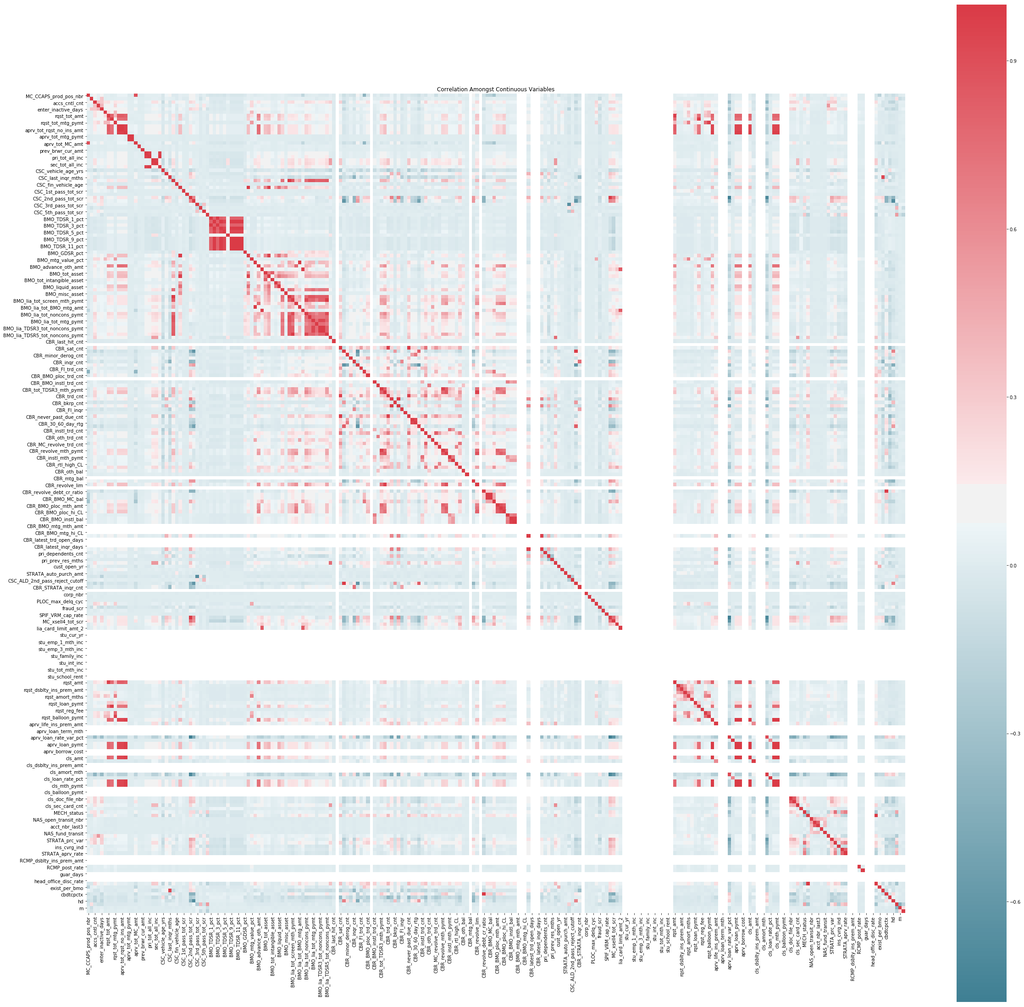

```python
f, ax = plt.subplots(figsize=(40, 40))
corr = X_train_num.corr()
sns.heatmap(corr, mask=np.zeros_like(corr, dtype=np.bool),
            cmap=sns.diverging_palette(220, 10, as_cmap=True),
            square=True, ax=ax)
plt.title("Correlation Amongst Continuous Variables")
```

## Correlation against Target - Continuous

[output not shown]

[figure not shown]

```python
f, ax = plt.subplots(figsize=(5, 50))
sns.heatmap(pd.DataFrame([np.absolute(np.corrcoef(y_train, X_train_num[col])[1, 0]) for col in X_train_num.columns],
                         index=list(X_train_num.columns)), ax = ax)
plt.title("Absolute Correlation against Target - Continuous Variables")
```

```python
cat_vars = var_types(X_train, exclude_dates)['cat_vars']
```

For categoricals, lets create a defined function which calculates the squard root of R Squared based on a linear model

```python
def abs_corr(data, y):

    abs_corr = []
    lm = linear_model.LinearRegression()

    for col in data.columns:
        x = pd.get_dummies(data[col]).values
        lm.fit(x, y)
        y_pred = lm.predict(x)
        abs_corr.append(np.sqrt(np.max([0,r2_score(y, y_pred)])))

    abs_corr = pd.DataFrame(abs_corr, index = list(data.columns))

    return abs_corr
```

## $\sqrt{R^{2}}$ against Target - Categorical Variables

```
Text(0.5,1,'Sqrt R2 - against Target - Categorical Variables')
```

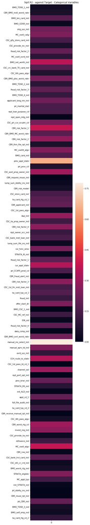

```python
f, ax = plt.subplots(figsize=(5, 50))
sns.heatmap(pd.DataFrame(abs_corr(X_train_cat, y_train),
                         index= list(X_train_cat.columns)), ax = ax)
plt.title("Sqrt R2 - against Target - Categorical Variables")
```

# Function for feature selections - ChiSquare and Mutual Information Score

```python
def uni_variate_tests(X_train,y_train):

    print("Calculating chi_test statistics for all features...")
    chi_test = chi2(X_train[list(X_train.columns)], y_train)
    chi2_stat = chi_test[0]

    chi2_stat = pd.DataFrame(chi_test[0], index = list(X_train.columns)).\
    sort_values(by = 0, ascending = False)

    p_val = pd.DataFrame(chi_test[1], index = list(X_train.columns)).\
    sort_values(by = 0, ascending = True)

    print("Calculating mi_scores for all features...")

    mi_score = []
    for col in X_train.columns:
        mi_score.append(mutual_info_score(X_train[col].values, y_train))

    mi_score = pd.DataFrame(mi_score, index = list(X_train.columns)).sort_values(by = 0, ascending = False)

    print('Done!')
    return {'chi2_stat': chi2_stat, 'p_val' : p_val, 'mi_score':mi_score}
```

```python
uni_variate_analysis = uni_variate_tests(X_train, y_train)
```

```
Calculating chi_test statistics for all features...
Calculating mi_scores for all features...
Done!
```

```
Text(0.5,1,'Scores - Univariate Chi Square Test')
```

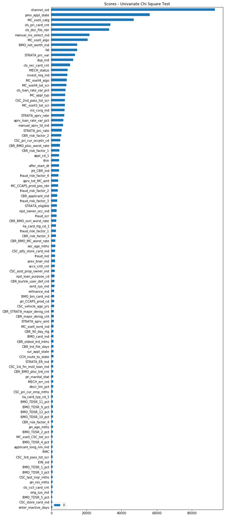

```python
chi_res = uni_variate_analysis['chi2_stat'].sort_values(by = 0, ascending = False).head(100)
chi_plt = chi_res.plot(kind = 'barh')
plt.gca().invert_yaxis()
chi_plt.figure.set_size_inches(10, 30)
chi_plt.set_title("Scores - Univariate Chi Square Test")
```

$$I(X;Y) = \sum_{y}\sum_{x}p(x, y)log(\frac{p(x,y)}{p(x)p(y)})$$

```
Text(0.5,1,'Mutual Information Score')
```

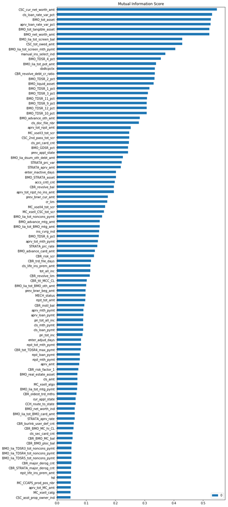

```python
mi_score_head = uni_variate_analysis['mi_score'].sort_values(by = 0, ascending = False).head(100)
mis_plt = mi_score_head.plot(kind = 'barh')
plt.gca().invert_yaxis()
mis_plt.figure.set_size_inches(10, 30)
mis_plt.set_title("Mutual Information Score")
```

# Feature importance calculation using XG Boost

Model Assumptions:

- Max depth of each tree is 10
- Minimum child weight controls when the tree building should terminate based comparing the sum of the instance weights, set to 1
- Objective function is a binary logistic
- Subsample ratio of the training instances set to 50%
- Subsample ratio of columns when constructing each tree set to 30%
- Subsample ratio of columns for each split, in each level, also set to 30%
- Positive/negative weight control set to number or reject/number of accept

The parameters for regularizations are default set to zero.

```python
def XGB_feat_importance(X_train, y_train, pop_count):
    clf = xgb.XGBClassifier(max_depth = 10, min_child_weight = 1,
                            learning_rate = 0.1, n_estimators = 500,
                            silent = 0, objective = 'reg:logistic',
                            gamma = 0, max_delta_step = 0,
                            subsample = 0.5, colsample_bytree = 0.3,
                            colsample_bylevel = 0.3, reg_alpha = 0,
                            reg_lambda = 0, scale_pos_weight = pop_count[0]/pop_count[1],
                            seed = 1, missing = None)
    clf.fit(X_train, y_train, verbose=True)
    ax = plot_importance(clf)
    fig = ax.figure
    fig.set_size_inches(10, 60)
    plt.show()

    return {'clf':clf}
```

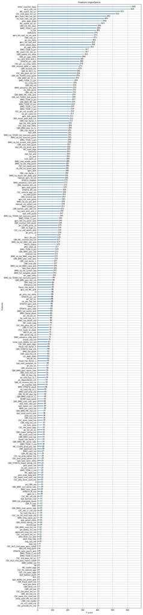

```
CPU times: user 57min 21s, sys: 26.6 s, total: 57min 47s
Wall time: 2min 22s
```

```python
%time var_import = XGB_feat_importance(X_train, y_train, pop_count)
```